# examMarks Package

## Marking Students

- To mark the student answers for all the exams use the **markStudents()** function
- This function takes the directory where everything is located as input
  - This function uses markStudentsForExam(), so all relevant files must be in the same directory
- There is also the option to have the output show on the console or be written into a folder using the writeToFile parameter
- If writeToFile = FALSE, a list of dataframes is created with each one representing the marked answers for a given exam

```r
summary(markStudents(fileDir = './'))
```

```
##       Length Class      Mode
## BS281 4      data.frame list
## BS282 4      data.frame list
## BS283 4      data.frame list
## BS284 4      data.frame list
## BS285 4      data.frame list
```

- If writeToFile = TRUE, a folder is created with a file for each exams marks

## Marking Students

- Using the function **examHist()**, a histogram can be generated using a list containing dataframes for each moduleID and the moduleID being assessed
- each list dataframe should have columns of studentID, degree course, and mark

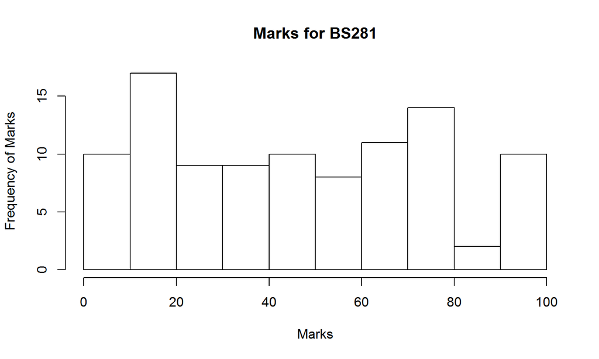

```r
examHist(testData, 'BS281')
```

## Data Analysis

- Using the function **moduleHist()**, a histogram can be generated using a dataframe and the degree subject being assessed
- The dataframe should have columns of studentID, degree course, and mark

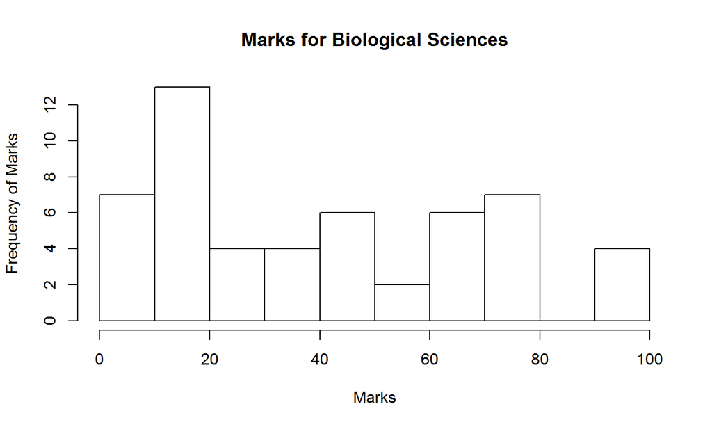

```r
moduleHist(testMarks, 'Biological Sciences')
```

## Data Analysis

- To analyse the difference in marks between the two degree course within a given module use **testWithinModule()**
- Either a t-test or a wilcoxon test is run
  - A normality test is run to determine which test will be run

```r
testWithinModule(testData, 'BS281')
```

```
##
##  Wilcoxon rank sum test with continuity correction
##
## data:  data[data[, 2] == "Genetics", 3] and data[data[, 2] == "Biological Sciences", 3]
## W = 1569, p-value = 0.02566
## alternative hypothesis: true location shift is not equal to 0
```

## Data Analysis

- To analyse the difference in marks between the two degree course for the overall marks use **testBetweenCourse()**
- Either a t-test or a wilcoxon test is run
  - A normality test is run to determine which test will be run

```r
testBetweenCourse(testMarks)
```

```
##
##  Wilcoxon rank sum test with continuity correction
##
## data:  data[data[, 2] == "Genetics", 3] and data[data[, 2] == "Biological Sciences", 3]
## W = 1086.5, p-value = 0.2624
## alternative hypothesis: true location shift is not equal to 0
```